# 住宅購入と空き家問題

供託金制度の役割

岩田真一郎（神奈川大学経済学部）

2025-09-08作成，2025-09-19改訂

［PDF形式：258KB］

日本の住宅購入者は，再販売価格を考慮せずに住宅を購入すると考えられています．その理由の一つとして，再販売市場（既存住宅市場，中古住宅市場と同じ意味です）の規模が小さい（薄い）ために，再販売が期待できないことがあげられます．それでは，市場規模はどれほど小さいのでしょうか？これを示す指標として，よく引用されるのが国土交通省（2024）が用意している住宅取引に占める既存住宅の流通割合（流通シェア）（図1A）になります．

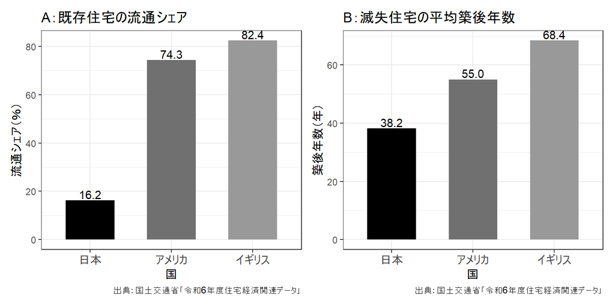

図1：住宅の利活用期間と既存住宅の流通の国際比較

図1Aから，日本の住宅取引は大半が新築住宅で，既存住宅の割合は16.2％ほどにとどまっていることがわかります．それに対して，アメリカやイギリスでは取引の大半が既存住宅です．[^1] <sup>,</sup> [^2]

家計は住宅の価値を保持しようと維持管理しても，再販売が難しいため，こうした動機も弱くなります．その結果，建物寿命（滅失住宅の平均築後年数）は短くなります．図1Bは，アメリカの建物寿命が55年，イギリスが約70年に対し，日本は40年未満と短命です．

それでは住宅の最終的な行く先はどうなるのでしょうか？少子化が進んでいなかった人口増加期の時代は，土地の希少価値が高く，多くの住宅は子に相続されていました．そして，相続した子は，譲り受けた住宅を維持管理しながら住み続けるか，譲り受けた住宅を取り壊して新しい家を建てることが一般的でした．

しかし，少子化や人口減少の時代になると，住宅は相続されても活用されず，そのまま空き家として放置されるようになりました（**相続空き家**）．その結果，一部（多く？）の空き家で維持管理が行き届かず，周辺に悪影響を及ぼす場面も見られるようになりました．冒頭で，住宅購入者は，再販売価格を考慮せずに住宅を購入すると述べました．しかし，購入した住宅が空き家になり，周辺に悪影響を及ぼすことまで考慮して，住宅を購入する家計は少ないかもしれません．すなわち，住宅購入者は購入した空き家が将来時点で負の**外部性**を発揮することまでは予想していないのです．[^3]

このような周辺住民に対する負の外部性に対して、政府は次のような対策を講じています．まず，維持管理が行き届かない空き家（**管理不全空家**）に対しては，固定資産税や都市計画税を増額する措置を取っています．[^4]次に，状態のさらに悪い空き家（**特定空家**）には，行政上の罰金を科し，場合によっては行政代執行により強制的に撤去し，その費用を空き家の所有者に請求しています．

空き家になる前に，家の将来を考えるように動きかける取り組みも広がっています．例えば世田谷区では，住まいの終活をテーマにしたパンフレットやワークシートを用意し，区民に事前の準備を促しています（世田谷区，2025；森田，2025）．

経済学的には市場メカニズムを使った空き家対策が有効だと考えられます．それは，将来の解体費用を供託金（デポジット）として事前に確保しておき，そのお金で建物を解体するというものです（米山，2021）．本稿では，ミクロ経済学を用いてこのメカニズムを説明します．

# 1 住宅取引と負の外部性

図2において，住宅市場の均衡点は需要曲線D<sub>0</sub>と供給曲線S<sub>0</sub>の交点Kで決定します．このとき，均衡価格はP<sub>0</sub>，均衡取引量ははH<sub>0</sub>です．

ここで，空き家問題を考慮するため，極端な仮定を考え，取引されている住宅は将来すべて空き家になり，周辺住民に対して，取引量1単位につきzの大きさの負の外生を発生するとしましょう．将来，住宅購入者が周辺住民が被る負の外部性を補償するならば，取引量1単位につきzの補償に備え，需要曲線はD<sub>0</sub>からD<sub>1</sub>のように下方シフトします．その結果，需要曲線D<sub>1</sub>と供給曲線S<sub>0</sub>の交点はC点に移動し，価格はP<sub>1</sub>に低下し，取引量はH<sub>1</sub>単位に減少します．これから見るように，C点において社会的余剰が最大になるため，C点を最適点とよぶことにします．

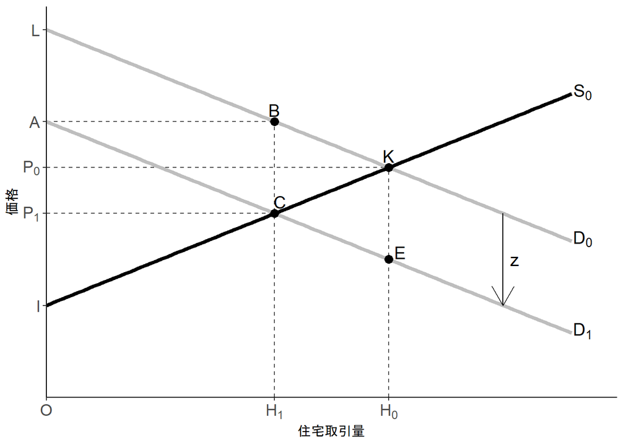

図2：住宅取引の負の外部性と供託金

負の外部性の問題は，住宅購入者がzを考慮せず，住宅需要量を決定する点でした．そこで最初に，均衡点Kにおける社会的余剰の大きさを調べてみましょう．均衡点Kにおいては，消費者余剰が面積LKP<sub>0</sub>，生産者余剰が面積IKP<sub>0</sub>になります．ただし，将来の空き家化は周辺住民に対して，面積LKEAの外部費用を生じさせます．社会的余剰は消費者余剰と生産者余剰の合計から外部費用を差し引くことになるため，面積ACI − CKEになります．

次に，最適点Cにおける社会的余剰を調べてみましょう．住宅購入者の便益LBH<sub>1</sub>Oから支出P<sub>1</sub>CH<sub>1</sub>Oを差し引くと，面積LBCP<sub>1</sub>が得られます．しかし，このうち面積LBCAは周辺住民に対する補償金になるため，消費者余剰はこの補償金を差し引いた面積ACP<sub>1</sub>になります．生産者余剰は面積P<sub>1</sub>CIです．周辺住民は将来，面積LBCAの外部費用を被りますが，これはちょうど住宅購入者によって補償されるため，余剰はゼロになります．最終的に，社会的余剰は面積ACIになり，均衡点における社会的余剰よりも面積CKEだけ大きくなります．

# 2 供託金と負の外部性の内部化

現実では，空き家の負の外部性に対して事後的に対策が捉えています．住宅購入者は負の外生を考慮せず，住宅取引に臨むため，住宅取引量は図2のH<sub>0</sub>のように過大になります．その結果，面積LKEAのような過大な外部費用が生じてしまうのです．

この外部費用の負担を回避しようと，一部の相続人が所有者を明確にせず放置するため，所有者不明の事例が社会問題となっています（吉原，2017）．

供託金は，事前的な対策として，住宅購入時点において住宅購入者に課されます．この結果，住宅需要曲線が下方シフトし，第1節で述べたように負の外部性を内部化され，最適取引量H<sub>1</sub>を実現させます．米山（2021）は，解体費用として供託金を提案しており、この仕組みによって将来，空き家が解体される場合には，空き家が存在しないという意味で周辺の外部費用はゼロとなります。ここで，解体の単位費用をzとすると，本稿と同様の結論を得ることができます．

# 参考文献

- 国土交通省（2024）[「令和6年住宅経済関連データ」](https://www.mlit.go.jp/statistics/details/t-jutaku-2_tk_000002.html)（アクセス日：2025-09-08）．↩︎
- 世田谷区（2025）[「ガイドブック「せたがや“家”の終活」のご案内」](https://www.city.setagaya.lg.jp/02066/3882.html)（アクセス日：2025-09-08）．↩︎
- 森田聡子（2025）[「都市にも空き家 「最多自治体」世田谷区の取り組み 実家を「放置空き家」にしない方法（3）」](https://www.nikkei.com/article/DGXZQOUB10BDV0Q5A410C2000000/)『日本経済新聞』2025年4月12日（アクセス日：2025-09-08）．↩︎
- 吉原祥子（2017）『[人口減少時代の土地問題](https://www.chuko.co.jp/shinsho/2017/07/102446.html)』中公新書2446．↩︎
- 米山秀隆（2021）[「人口減少時代の住宅・土地制度を」](https://www.nikkei.com/article/DGXZQOGH163840W1A210C2000000/)『日本経済新聞』2021年3月12日（アクセス日：2025-09-08）．↩︎
- Glaeser, E. L. (2020). [Urbanization and its discontents](https://www.nber.org/papers/w26839). National Bureau of Economic Research, Working Paper 26839.↩︎
- Gyourko, J., & McCulloch, S. (2023). [Minimum lot size restrictions: Impacts on urban form and house price at the border](https://www.nber.org/papers/w31710). National Bureau of Economic Research, Working Paper 31710.↩︎

# R環境

**セッション情報**

- R version 4.4.3 (2025-02-28 ucrt)
  - RStudio 2025.05.1+513
  - rmarkdown_2.29

**使用したパッケージ**

- `tidyverse`
- `patchwork`

# リンク

[都市経済学講義ノート](https://shinichiro-iwata.github.io/lecture-notes-urban-econ/)

[Rによる地理空間データの可視化](https://shinichiro-iwata.github.io/geospatial-data-visualization/)

[Shinichiro Iwata](https://shinichiro-iwata.github.io/)

**アイコン**

Font Awesome 6.3.0

**生成AIの使用について**

ChatGPTのサービスを利用した後，内容を確認し，必要に応じて編集を行いました．

[^1]: アメリカやイギリスでは，景観保護や用途・密度に関する厳しい土地利用規制があります（ミクロ経済学的には，住宅建設による周囲への負の外部性を抑制することを目的としています）．そのため，建築には開発許可の取得に長い時間を要し，新築住宅の供給は制約されやすく，既存住宅の取引が大きな比重を占めています．
[^2]: 世界的な資材価格上昇を背景に，大都市を中心に住宅価格が高騰しています．こうした背景とは別に，経済学者は以前から，大都市で住宅価格が高止まりする一因として，厳しい土地利用規制の存在を指摘してきました（Glaeser，2020）．住宅価格の高騰が続く中，規制緩和によって新規住宅の取引を増やす（→お手頃な住宅を増やす）ことが有効と考えられています（Gyourko & McCulloch，2023）．
[^3]: 外部性とは，ある主体の行動が市場を経由せずに他の主体の厚生に影響を及ぼすことをいいます．特に，その影響が悪影響の場合は負の外部性とよびます．
[^4]: 空き家を活用せずに所有し続ける場合でも，所有者である相続人は，市町村税（東京都23区内では都税）として，固定資産税（所有する土地，家屋に対して課され，使途が自由な税）と都市計画税（都市計画施設や市街地開発のために使途が制限される税）を毎年（または3カ月ごとに）支払う必要があります．固定資産税は評価額の1.4％，都市計画税は0.3％以下ですが，住宅用地には軽減措置があります．小規模住宅用地（200㎡以下）では，固定資産税の課税標準額は評価額の6分の1に，都市計画税の課税標準額は評価額の3分の1に軽減されます．一般住宅用地（200㎡を超える部分）では，それぞれ3分の1，3分の2に軽減されます．例えば，[路線価](https://ja.wikipedia.org/wiki/%E8%B7%AF%E7%B7%9A%E4%BE%A1)が3万円/㎡の小規模住宅用地200㎡を相続した場合，土地の評価額は600万円（200㎡×3万円）になります。これに軽減措置を適用すると，固定資産税の課税標準額は100万円（600万円の6分の1），都市計画税の課税標準額は200万円（600万円の3分の1）となります．したがって、固定資産税は14,000円（100万円×0.014），都市計画税は最大で6,000円（200万円×0.003），合計でおおむね2万円程度の負担になります．